# PD4

Adam Rydelek

13.04.2019

# 1 Wprowadzenie

Będziemy badać metodę *svm* na zbiorze **apartments** z pakietu `DALEX` i zbiorze **auto_price** z `OpenML'a`. Poniżej znajduje się podsumowanie zbiorów.

## 1.1 Apartments

```r
summary(apt)
```

```
##     m2.price    construction.year    surface           floor
##  Min.   :1607   Min.   :1920      Min.   : 20.00   Min.   : 1.000
##  1st Qu.:2857   1st Qu.:1943      1st Qu.: 53.00   1st Qu.: 3.000
##  Median :3386   Median :1965      Median : 85.50   Median : 6.000
##  Mean   :3487   Mean   :1965      Mean   : 85.59   Mean   : 5.623
##  3rd Qu.:4018   3rd Qu.:1988      3rd Qu.:118.00   3rd Qu.: 8.000
##  Max.   :6595   Max.   :2010      Max.   :150.00   Max.   :10.000
##
##     no.rooms           district
##  Min.   :1.00   Mokotow    :107
##  1st Qu.:2.00   Wola       :106
##  Median :3.00   Ursus      :105
##  Mean   :3.36   Ursynow    :103
##  3rd Qu.:4.00   Srodmiescie:100
##  Max.   :6.00   Bemowo     : 98
##                 (Other)    :381
```

Na tym zbiorze będziemy wykonywać regresję na zmiennej *m2.price*, czyli cenie za metr kwadratowy mieszkania.

## 1.2 Auto_price

```r
summary(cars)
```

```
##  symboling normalized.losses   wheel.base         length
##  -3: 0     Min.   : 65.0     Min.   : 86.60   Min.   :141.1
##  -2: 3     1st Qu.: 94.0     1st Qu.: 94.50   1st Qu.:165.7
##  -1:20     Median :113.0     Median : 96.90   Median :172.4
##  0 :48     Mean   :121.1     Mean   : 98.26   Mean   :172.4
##  1 :46     3rd Qu.:148.0     3rd Qu.:100.80   3rd Qu.:177.8
##  2 :29     Max.   :256.0     Max.   :115.60   Max.   :202.6
##  3 :13
##      width           height       curb.weight    engine.size
##  Min.   :60.30   Min.   :49.40   Min.   :1488   Min.   : 61.0
##  1st Qu.:64.00   1st Qu.:52.25   1st Qu.:2066   1st Qu.: 97.0
##  Median :65.40   Median :54.10   Median :2340   Median :110.0
##  Mean   :65.61   Mean   :53.90   Mean   :2461   Mean   :119.2
##  3rd Qu.:66.50   3rd Qu.:55.50   3rd Qu.:2810   3rd Qu.:135.0
##  Max.   :71.70   Max.   :59.80   Max.   :4066   Max.   :258.0
##
##       bore          stroke      compression.ratio   horsepower
##  Min.   :2.54   Min.   :2.070   Min.   : 7.00     Min.   : 48.00
##  1st Qu.:3.05   1st Qu.:3.105   1st Qu.: 8.70     1st Qu.: 69.00
##  Median :3.27   Median :3.270   Median : 9.00     Median : 88.00
##  Mean   :3.30   Mean   :3.236   Mean   :10.16     Mean   : 95.84
##  3rd Qu.:3.56   3rd Qu.:3.410   3rd Qu.: 9.40     3rd Qu.:114.00
##  Max.   :3.94   Max.   :4.170   Max.   :23.00     Max.   :200.00
##
##     peak.rpm       city.mpg      highway.mpg    binaryClass
##  Min.   :4150   Min.   :15.00   Min.   :18.00   P:105
##  1st Qu.:4800   1st Qu.:23.00   1st Qu.:28.00   N: 54
##  Median :5200   Median :26.00   Median :32.00
##  Mean   :5114   Mean   :26.52   Mean   :32.08
##  3rd Qu.:5500   3rd Qu.:31.00   3rd Qu.:37.00
##  Max.   :6600   Max.   :49.00   Max.   :54.00
##
```

Na powyższym zbiorze wykonamy klasyfikację zmiennej wieloklasowe: *symboling*

# 2 Parametry domyślne

## 2.1 Apartmets

### 2.1.1 Bez skalowania

Na początek sprawdzimy jak radzi sobie **svm** na zbiorach danych bez skalowania, aby to osiągnąć musimy zmienić domyślny parametr `scale` na *FALSE*. Sprawdzimy teraz jak sobie poradził model.

```r
kable(data.frame(r$aggr))
```

|  | r.aggr |
| --- | --- |
| mse.test.mean | 8.319938e+05 |
| rmse.test.rmse | 9.121370e+02 |
| rsq.test.mean | -1.692290e-02 |

Można zauważyć, że wyniki są fatalne, a błąd średniokwadratowy jest ogromny.

### 2.1.2 Ze skalowaniem

Teraz stworzymy learner **svm** z domyślnymi parametrami, czyli również z parametrem `scale` ustawionym na *TRUE*.

```r
kable(data.frame(r$aggr))
```

|  | r.aggr |
| --- | --- |
| mse.test.mean | 2.798643e+04 |
| rmse.test.rmse | 1.672915e+02 |
| rsq.test.mean | 9.655977e-01 |

Można zauważyć znaczną poprawę, jednak wyniki dalej nie są zadowalające.

## 2.2 Auto_price

### 2.2.1 Bez skalowania

Teraz sprawdzimy jak radzi sobie svm bez skalowania z klasyfikacją wieloklasową na zbiorze auto_price.

```r
kable(data.frame(r$aggr))
```

[output not shown]

### 2.2.2 Ze skalowaniem

```r
kable(data.frame(r$aggr))
```

|  | r.aggr |
| --- | --- |
| acc.test.mean | 0.6725806 |
| mmce.test.mean | 0.3274194 |

Ze skalowaniem wyniki są już na dobrym poziomie, ale również spróbujemy je poprawić w dalszej części.

# 3 Tuning parametrów

Aby poprawić działanie naszych learnerów, zarówno regresyjnego i klasyfikacyjnego wykorzystamy dwie metody tuningu parametrów: *Grid Search* i *Random Search*. Zajmiemy się dostrajaniem parametrów dla jądra gaussowskiego - **radial**. Za istotne parametry godne modyfikacji uznałem: **gamma** - parametr numeryczny **cost** - parametr numeryczny

```r
ps = makeParamSet(
  makeNumericParam("gamma", lower = -10, upper = 10),
  makeNumericParam("cost", lower = -10, upper = 50),
  makeDiscreteParam("kernel", values="radial")
)

ctrlRand = makeTuneControlRandom(maxit = 200L)

ctrlGrid = makeTuneControlGrid(resolution = 100L)
```

## 3.1 Apartments

### 3.1.1 Grid Search

```r
kable(data.frame(res1a$x))
```

| gamma | cost | kernel |
| --- | --- | --- |
| 0.1010101 | 7.575758 | radial |

```r
kable(data.frame(r$aggr))
```

|  | r.aggr |
| --- | --- |
| mse.test.mean | 2.553443e+04 |
| rmse.test.rmse | 1.597950e+02 |
| rsq.test.mean | 9.683218e-01 |

### 3.1.2 Random Search

```r
kable(data.frame(res1b$x))
```

| gamma | cost | kernel |
| --- | --- | --- |
| 0.1091751 | 10.08674 | radial |

```r
kable(data.frame(r$aggr))
```

|  | r.aggr |
| --- | --- |
| mse.test.mean | 2.719426e+04 |
| rmse.test.rmse | 1.649068e+02 |
| rsq.test.mean | 9.664622e-01 |

Można więc zauważyć poprawę wyników po tuningu parametrów dla obu sposobów. Lepszy tym razem okazał się Grid Search.

## 3.2 Auto_price

### 3.2.1 Grid Search

```r
kable(data.frame(res2a$x))
```

| gamma | cost | kernel |
| --- | --- | --- |
| 0.1010101 | 16.06061 | radial |

```r
kable(data.frame(r$aggr))
```

|  | r.aggr |
| --- | --- |
| acc.test.mean | 0.7483871 |
| mmce.test.mean | 0.2516129 |

### 3.2.2 Random Search

```r
kable(data.frame(res2b$x))
```

| gamma | cost | kernel |
| --- | --- | --- |
| 0.15727 | 17.48055 | radial |

```r
kable(data.frame(r$aggr))
```

|  | r.aggr |
| --- | --- |
| acc.test.mean | 0.7552419 |
| mmce.test.mean | 0.2447581 |

Tym razem lepiej spisał się Random Search. Accuracy w porównaniu do domyślnych parametrów poprawiło się znacznie, co pokazuje, że tuning parametrów ma sens.

# 4 Wizualizacja

```r
custom_predict_r <- function(object, newdata) {pred <- predict(object, newdata=newdata)
response <- pred$data$response
return(response)}

custom_predict_c <- function(object, newdata) {pred <- predict(object, newdata=newdata)
response <- pred$data[,1]
return(response)}


regr_lrnt <- makeLearner("regr.ranger", predict.type = "response")



classif_lrnt <- makeLearner("classif.ranger", predict.type="prob")


train1a = train(classif_lrn2, classif_tsk2)
train1b = train(classif_lrn2b, classif_tsk2)
train1c = train(classif_lrn3, classif_tsk2)
train1d = train(classif_lrn4, classif_tsk2)
train1t = train(classif_lrnt, classif_tsk2)

train2a = train(regr_lrn1, regr_tsk1)
train2b = train(regr_lrn1b, regr_tsk1)
train2c = train(regr_lrn2, regr_tsk1)
train2d = train(regr_lrn3, regr_tsk1)
train2t = train(regr_lrnt, regr_tsk1)

explainer1a <- explain(train2a, data = apt[,2:6], y = apt$m2.price, predict_function = custom_predict_r, label="No scaling")
explainer1b <- explain(train2b, data = apt[,2:6], y = apt$m2.price, predict_function = custom_predict_r, label="Scaling")
explainer1c <- explain(train2c, data = apt[,2:6], y = apt$m2.price, predict_function = custom_predict_r, label="Grid Tuning")
explainer1d <- explain(train2d, data = apt[,2:6], y = apt$m2.price, predict_function = custom_predict_r, label="Random Tuning")
explainer1t <- explain(train2t, data = apt[,2:6], y = apt$m2.price, predict_function = custom_predict_r, label="Ranger")

explainer2a <- explain(train1a, data = cars[,2:16], y = cars$symboling, predict_function = custom_predict_c, label="No scaling")
explainer2b <- explain(train1b, data = cars[,2:16], y = cars$symboling, predict_function = custom_predict_c, label="Scaling")
explainer2c <- explain(train1c, data = cars[,2:16], y = cars$symboling, predict_function = custom_predict_c, label="Grid Tuning")
explainer2d <- explain(train1d, data = cars[,2:16], y = cars$symboling, predict_function = custom_predict_c, label="Random Tuning")
explainer2t <- explain(train1t, data = cars[,2:16], y = cars$symboling, predict_function = custom_predict_c, label="Ranger")

pdp1a <- variable_response(explainer1a, variable = "construction.year", type = "pdp")
pdp1b <- variable_response(explainer1b, variable = "construction.year", type = "pdp")
pdp1c <- variable_response(explainer1c, variable = "construction.year", type = "pdp")
pdp1d <- variable_response(explainer1d, variable = "construction.year", type = "pdp")
pdp1t <- variable_response(explainer1t, variable = "construction.year", type = "pdp")

ale1a <- variable_response(explainer1a, variable = "surface", type = "ale")
ale1b <- variable_response(explainer1b, variable = "surface", type = "ale")
ale1c <- variable_response(explainer1c, variable = "surface", type = "ale")
ale1d <- variable_response(explainer1d, variable = "surface", type = "ale")
ale1t <- variable_response(explainer1t, variable = "surface", type = "ale")


pdp2a <- variable_response(explainer2a, variable = "horsepower", type = "pdp")
pdp2b <- variable_response(explainer2b, variable = "horsepower", type = "pdp")
pdp2c <- variable_response(explainer2c, variable = "horsepower", type = "pdp")
pdp2d <- variable_response(explainer2d, variable = "horsepower", type = "pdp")
pdp2t <- variable_response(explainer2t, variable = "horsepower", type = "pdp")

ale2a <- variable_response(explainer2a, variable = "city.mpg", type = "ale")
ale2b <- variable_response(explainer2b, variable = "city.mpg", type = "ale")
ale2c <- variable_response(explainer2c, variable = "city.mpg", type = "ale")
ale2d <- variable_response(explainer2d, variable = "city.mpg", type = "ale")
ale2t <- variable_response(explainer2t, variable = "city.mpg", type = "ale")
```

## 4.1 PDP

### 4.1.1 Apartments

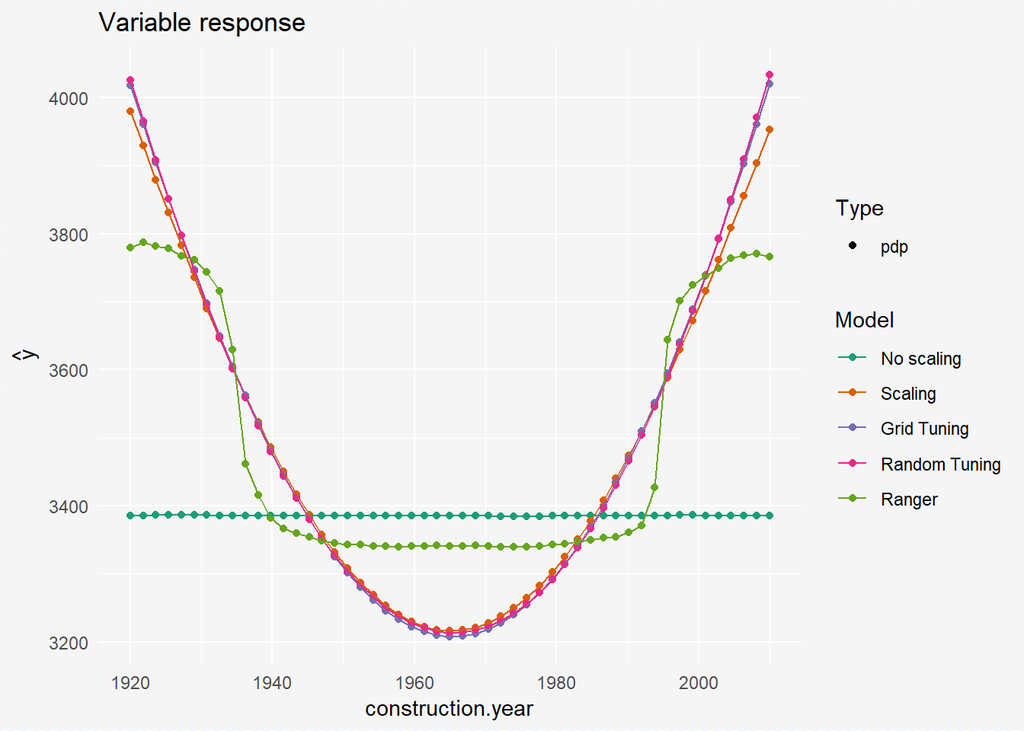

```r
plot(pdp1a,pdp1b,pdp1c,pdp1d,pdp1t)
```

### 4.1.2 Auto_price

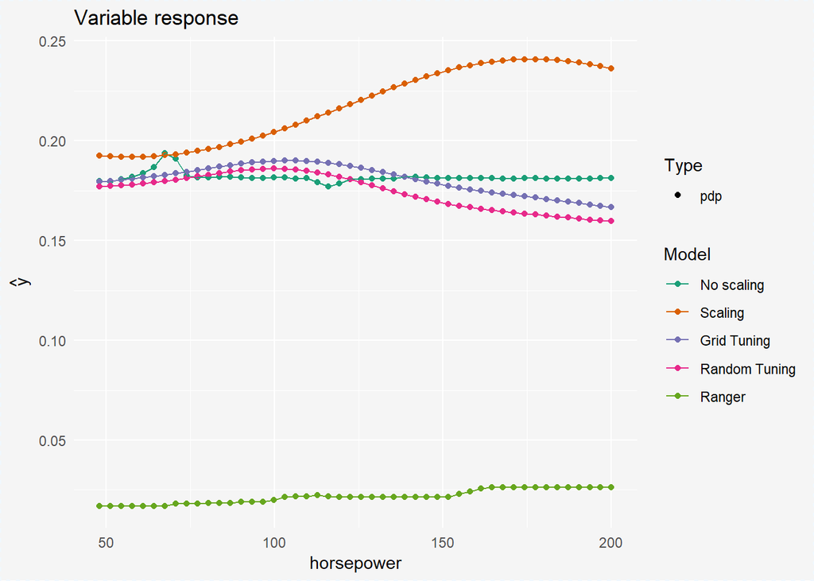

```r
plot(pdp2a,pdp2b,pdp2c,pdp2d,pdp2t)
```

## 4.2 ALE

### 4.2.1 Apartments

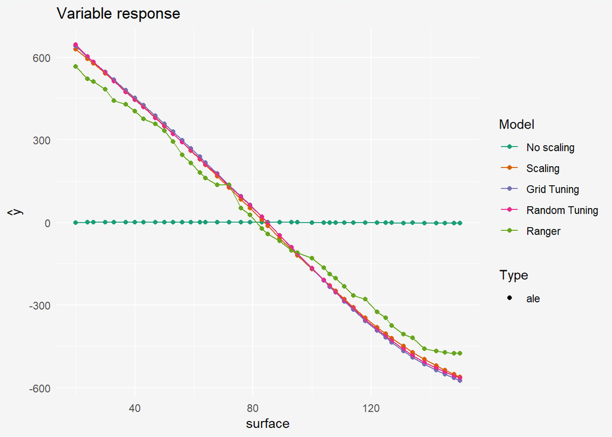

```r
plot(ale1a,ale1b,ale1c,ale1d,ale1t)
```

### 4.2.2 Auto_price

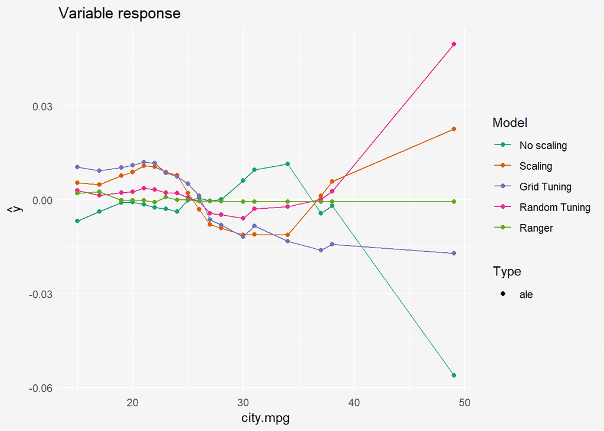

```r
plot(ale2a,ale2b,ale2c,ale2d,ale2t)
```

# 5 Podsumowanie

Podsumowując można zauważyć, że skalowanie w modelach z użyciem **svm** jest kluczowe. Ponad to osiągnęliśmy oczekiwany efekt - tuning parametrów poprawił działanie modelu i otrzymaliśmy lepsze wyniki. Dzięki powyższym wykresom PDP i ALE można zauważyć, że svm bez skalowania działa całkiem inaczej, niż ten domyślny ze skanowaniem, co pokazuje jak istotne jest skalowanie. Porównując różne svm i ranger, czyli strukturę drzewiastą można zauważyć, że jego wykresy PDP okazały się na dłuższym odcinku liniowe, niż svm. Natomiast dla wybranych wykresów ALE można zauważyć, że wyniki są bardziej zbliżone, jednak nadal widać różnicę.